# World Happiness Report

세계행복보고서는 유엔 산하 자문기구인 지속가능발전해법네트워크가 매년 발표하는 보고서로, 세계 각 나라 거주민들의 행복을 정량화하여 행복지수로 표현하고, 이를 통해 정부, 기업 및 시민 사회가 행복에 관한 복지를 평가 및 피드백 할 수 있도록 한다. 각 나라별 1000명의 사람들에게 자신의 삶의 만족도를 조사한 갤럽의 월드 폴(World Poll)을 바탕으로 1인당 국내총생산(GDP), 사회적 지지, 기대 수명, 선택의 자유, 관용, 부정부패 인식 등 6가지 변수를 고려하여 평가한다.

### 행복 지수(Ladder Score)에 영향을 끼치는 6가지 변수

- **1인당 국내총생산(Logged GDP per capita)** : 1인당 GDP 수준 (1인당 소득수준)
- **사회적 지지(Social Support)** : 어려움에 처했을 때, 도움을 요청할 가족 혹은 친구가 있는지 여부
- **기대 수명(Healthy Life Expectancy)** : 출생부터 건강하게 살 수 있는 기대 수명
- **선택의 자유(Freedom to make life choices)** : 하고 싶은 일을 선택할 자유에 대하여 만족하는지 여부
- **관용(Generosity)** : 지난 한달 동안 기부한 적이 있는지 여부
- **부정부패 인식(Perceptions of corruption)** : 정부나 기업에 부해가 만연하다고 생각하는지 여부

### 데이터 분석

```python
happiness_df.head(5)
```

|  | Country name | Regional indicator | Ladder score | Standard error of ladder score | upperwhisker | lowerwhisker | Logged GDP per capita | Social support | Healthy life expectancy | Freedom to make life choices | Generosity | Perceptions of corruption | Ladder score in Dystopia | Explained by: Log GDP per capita | Explained by: Social support | Explained by: Healthy life expectancy | Explained by: Freedom to make life choices | Explained by: Generosity | Explained by: Perceptions of corruption | Dystopia + residual |
| --- | --- | --- | --- | --- | --- | --- | --- | --- | --- | --- | --- | --- | --- | --- | --- | --- | --- | --- | --- | --- |
| 0 | Finland | Western Europe | 7.842 | 0.032 | 7.904 | 7.780 | 10.775 | 0.954 | 72.0 | 0.949 | -0.098 | 0.186 | 2.43 | 1.446 | 1.106 | 0.741 | 0.691 | 0.124 | 0.481 | 3.253 |
| 1 | Denmark | Western Europe | 7.620 | 0.035 | 7.687 | 7.552 | 10.933 | 0.954 | 72.7 | 0.946 | 0.030 | 0.179 | 2.43 | 1.502 | 1.108 | 0.763 | 0.686 | 0.208 | 0.485 | 2.868 |
| 2 | Switzerland | Western Europe | 7.571 | 0.036 | 7.643 | 7.500 | 11.117 | 0.942 | 74.4 | 0.919 | 0.025 | 0.292 | 2.43 | 1.566 | 1.079 | 0.816 | 0.653 | 0.204 | 0.413 | 2.839 |
| 3 | Iceland | Western Europe | 7.554 | 0.059 | 7.670 | 7.438 | 10.878 | 0.983 | 73.0 | 0.955 | 0.160 | 0.673 | 2.43 | 1.482 | 1.172 | 0.772 | 0.698 | 0.293 | 0.170 | 2.967 |
| 4 | Netherlands | Western Europe | 7.464 | 0.027 | 7.518 | 7.410 | 10.932 | 0.942 | 72.4 | 0.913 | 0.175 | 0.338 | 2.43 | 1.501 | 1.079 | 0.753 | 0.647 | 0.302 | 0.384 | 2.798 |

### 각 Column의 데이터 타입

```python
happiness_df.dtypes
```

```
Country name                                   object
Regional indicator                             object
Ladder score                                  float64
Standard error of ladder score                float64
upperwhisker                                  float64
lowerwhisker                                  float64
Logged GDP per capita                         float64
Social support                                float64
Healthy life expectancy                       float64
Freedom to make life choices                  float64
Generosity                                    float64
Perceptions of corruption                     float64
Ladder score in Dystopia                      float64
Explained by: Log GDP per capita              float64
Explained by: Social support                  float64
Explained by: Healthy life expectancy         float64
Explained by: Freedom to make life choices    float64
Explained by: Generosity                      float64
Explained by: Perceptions of corruption       float64
Dystopia + residual                           float64
dtype: object
```

### 이상치, 결측치 확인

```python
happiness_df.describe()
```

|  | Ladder score | Standard error of ladder score | upperwhisker | lowerwhisker | Logged GDP per capita | Social support | Healthy life expectancy | Freedom to make life choices | Generosity | Perceptions of corruption | Ladder score in Dystopia | Explained by: Log GDP per capita | Explained by: Social support | Explained by: Healthy life expectancy | Explained by: Freedom to make life choices | Explained by: Generosity | Explained by: Perceptions of corruption | Dystopia + residual |
| --- | --- | --- | --- | --- | --- | --- | --- | --- | --- | --- | --- | --- | --- | --- | --- | --- | --- | --- |
| count | 149.000000 | 149.000000 | 149.000000 | 149.000000 | 149.000000 | 149.000000 | 149.000000 | 149.000000 | 149.000000 | 149.000000 | 149.00 | 149.000000 | 149.000000 | 149.000000 | 149.000000 | 149.000000 | 149.000000 | 149.000000 |
| mean | 5.532839 | 0.058752 | 5.648007 | 5.417631 | 9.432208 | 0.814745 | 64.992799 | 0.791597 | -0.015134 | 0.727450 | 2.43 | 0.977161 | 0.793315 | 0.520161 | 0.498711 | 0.178047 | 0.135141 | 2.430329 |
| std | 1.073924 | 0.022001 | 1.054330 | 1.094879 | 1.158601 | 0.114889 | 6.762043 | 0.113332 | 0.150657 | 0.179226 | 0.00 | 0.404740 | 0.258871 | 0.213019 | 0.137888 | 0.098270 | 0.114361 | 0.537645 |
| min | 2.523000 | 0.026000 | 2.596000 | 2.449000 | 6.635000 | 0.463000 | 48.478000 | 0.382000 | -0.288000 | 0.082000 | 2.43 | 0.000000 | 0.000000 | 0.000000 | 0.000000 | 0.000000 | 0.000000 | 0.648000 |
| 25% | 4.852000 | 0.043000 | 4.991000 | 4.706000 | 8.541000 | 0.750000 | 59.802000 | 0.718000 | -0.126000 | 0.667000 | 2.43 | 0.666000 | 0.647000 | 0.357000 | 0.409000 | 0.105000 | 0.060000 | 2.138000 |
| 50% | 5.534000 | 0.054000 | 5.625000 | 5.413000 | 9.569000 | 0.832000 | 66.603000 | 0.804000 | -0.036000 | 0.781000 | 2.43 | 1.025000 | 0.832000 | 0.571000 | 0.514000 | 0.164000 | 0.101000 | 2.509000 |
| 75% | 6.255000 | 0.070000 | 6.344000 | 6.128000 | 10.421000 | 0.905000 | 69.600000 | 0.877000 | 0.079000 | 0.845000 | 2.43 | 1.323000 | 0.996000 | 0.665000 | 0.603000 | 0.239000 | 0.174000 | 2.794000 |
| max | 7.842000 | 0.173000 | 7.904000 | 7.780000 | 11.647000 | 0.983000 | 76.953000 | 0.970000 | 0.542000 | 0.939000 | 2.43 | 1.751000 | 1.172000 | 0.897000 | 0.716000 | 0.541000 | 0.547000 | 3.482000 |

```python
happiness_df.isnull().sum()
```

```
Country name                                  0
Regional indicator                            0
Ladder score                                  0
Standard error of ladder score                0
upperwhisker                                  0
lowerwhisker                                  0
Logged GDP per capita                         0
Social support                                0
Healthy life expectancy                       0
Freedom to make life choices                  0
Generosity                                    0
Perceptions of corruption                     0
Ladder score in Dystopia                      0
Explained by: Log GDP per capita              0
Explained by: Social support                  0
Explained by: Healthy life expectancy         0
Explained by: Freedom to make life choices    0
Explained by: Generosity                      0
Explained by: Perceptions of corruption       0
Dystopia + residual                           0
dtype: int64
```

## 행복 지수(Ladder score)와 6가지 변수들

- **행복지수에 영향을 줄 수 있는 6가지 변수들**에 대하여 어떤 양상을 보이는지 확인
- 행복지수와 관련이 높은 변수에는 1인 국내총생산, 사회적 지지도, 기대 수명이 있다.

```python
variable = ['Ladder score', 'Logged GDP per capita','Social support','Healthy life expectancy','Freedom to make life choices','Generosity','Perceptions of corruption']
happiness_df[variable].corr()
```

|  | Ladder score | Logged GDP per capita | Social support | Healthy life expectancy | Freedom to make life choices | Generosity | Perceptions of corruption |
| --- | --- | --- | --- | --- | --- | --- | --- |
| Ladder score | 1.000000 | 0.789760 | 0.756888 | 0.768099 | 0.607753 | -0.017799 | -0.421140 |
| Logged GDP per capita | 0.789760 | 1.000000 | 0.785299 | 0.859461 | 0.432323 | -0.199286 | -0.342337 |
| Social support | 0.756888 | 0.785299 | 1.000000 | 0.723256 | 0.482930 | -0.114946 | -0.203207 |
| Healthy life expectancy | 0.768099 | 0.859461 | 0.723256 | 1.000000 | 0.461494 | -0.161750 | -0.364374 |
| Freedom to make life choices | 0.607753 | 0.432323 | 0.482930 | 0.461494 | 1.000000 | 0.169437 | -0.401363 |
| Generosity | -0.017799 | -0.199286 | -0.114946 | -0.161750 | 0.169437 | 1.000000 | -0.163962 |
| Perceptions of corruption | -0.421140 | -0.342337 | -0.203207 | -0.364374 | -0.401363 | -0.163962 | 1.000000 |

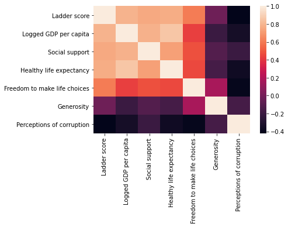

```python
sns.heatmap(happiness_df[variable].corr())
plt.show()
```

### 행복 지수 vs 1인당 국내총생산

- GDP가 높아질수록 행복지수도 높아진다.

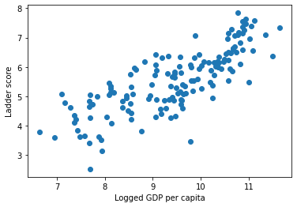

```python
plt.xlabel('Logged GDP per capita')
plt.ylabel('Ladder score')
plt.scatter(happiness_df['Logged GDP per capita'],happiness_df['Ladder score'])
plt.show()
```

### 행복 지수 vs 사회적 지지도

- 사회적 지지도가 높아질수록 행복지수도 높아진다.

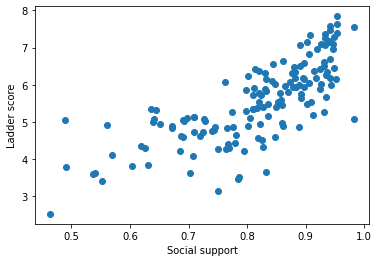

```python
plt.xlabel('Social support')
plt.ylabel('Ladder score')
plt.scatter(happiness_df['Social support'],happiness_df['Ladder score'])
plt.show()
```

### 행복 지수 vs 기대 수명

- 기대 수명이 높아질수록 행복지수도 높아진다.

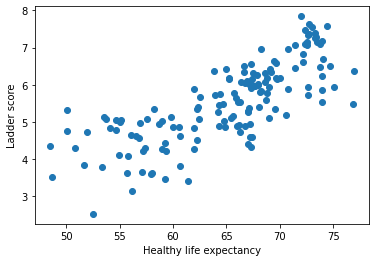

```python
plt.xlabel('Healthy life expectancy')
plt.ylabel('Ladder score')
plt.scatter(happiness_df['Healthy life expectancy'],happiness_df['Ladder score'])
plt.show()
```

### 행복 지수 vs 선택의 자유

- 2021년도의 선택의 자유는 대부분 0.6을 넘고, 높은 편이다. 하지만, 선택의 자유가 높아도 반드시 행복 지수가 높은 것이 아니다.

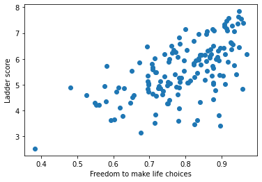

```python
plt.xlabel('Freedom to make life choices')
plt.ylabel('Ladder score')
plt.scatter(happiness_df['Freedom to make life choices'],happiness_df['Ladder score'])
plt.show()
```

### 행복 지수 vs 관용

- 기부를 많이 할수록 행복 지수가 높을 줄 알았는데 오히려 대부분 0이하의 값이 나왔다.
- 행복 지수와 관계 없이 대부분의 나라의 기부 수준은 낮았다.
- 오히려 관용 점수가 가장 높은 4개의 나라의 행복 지수는 6점 아래다.

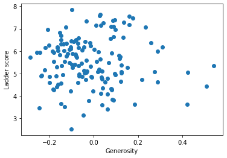

```python
plt.xlabel('Generosity')
plt.ylabel('Ladder score')
plt.scatter(happiness_df['Generosity'],happiness_df['Ladder score'])
plt.show()
```

### 행복 지수 vs 부정부패 인식

- 부정부패 인식의 정도가 높아질수록 행복지수도 낮아졌지만 정도가 심하지 않았다.
- 오히려 대부분의 나라들이 부정부패 인식 수준이 매우 높았고, 그에 따른 행복지수는 4~7에 몰려있다.

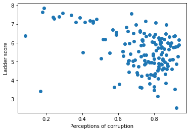

```python
plt.xlabel('Perceptions of corruption')
plt.ylabel('Ladder score')
plt.scatter(happiness_df['Perceptions of corruption'],happiness_df['Ladder score'])
plt.show()
```

### 지역별 행복 지수

- 대체로 GDP가 높은 지역일수록 행복 지수가 높다.

```python
Region_df = happiness_df[['Ladder score','Regional indicator','Logged GDP per capita']].groupby('Regional indicator').median().iloc[:,:]
Region_df = Region_df.sort_values(by='Ladder score' ,ascending=True)
Region_df
```

| Regional indicator | Ladder score | Logged GDP per capita |
| --- | --- | --- |
| Sub-Saharan Africa | 4.6160 | 7.9345 |
| Middle East and North Africa | 4.8870 | 9.5840 |
| South Asia | 4.9340 | 8.4580 |
| Southeast Asia | 5.3840 | 9.0760 |
| Commonwealth of Independent States | 5.4715 | 9.5280 |
| East Asia | 5.7610 | 10.6310 |
| Latin America and Caribbean | 5.9920 | 9.4530 |
| Central and Eastern Europe | 6.0780 | 10.2840 |
| Western Europe | 7.0850 | 10.8230 |
| North America and ANZ | 7.1430 | 10.7860 |

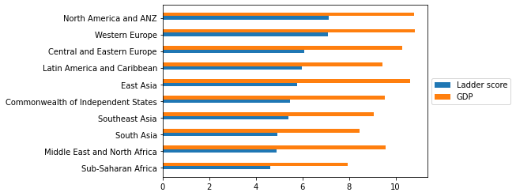

```python
bar_width = 0.2
x = np.arange(len(Region_df.index))
plt.barh(x-0.0, Region_df.iloc[:,0],bar_width,label = 'Ladder score')
plt.barh(x+0.2, Region_df.iloc[:,1],bar_width,label = 'GDP')
plt.yticks(x,Region_df.index)
plt.legend(loc = 'center left', bbox_to_anchor=(1,0.5))
plt.show()
```